# analysis

```python
# importing liberaries

import pandas as pd
import numpy as np
import matplotlib.pyplot as plt
```

```python
# importing the datasets
countries = pd.read_csv('data/countries.tsv', sep='\t')
missions = pd.read_csv('data/missions.tsv', sep='\t')
places = pd.read_csv('data/places.tsv', sep='\t')
users = pd.read_csv('data/users.tsv', sep='\t')
```

### Assessing the Data

```python
countries.head()
```

|  | #alpha2 | country | continent |
| --- | --- | --- | --- |
| 0 | AD | Andorra | EU |
| 1 | AE | United Arab Emirates | AS |
| 2 | AF | Afghanistan | AS |
| 3 | AG | Antigua and Barbuda | NaN |
| 4 | AI | Anguilla | NaN |

```python
missions.head()
```

|  | #mission_id | user_id | place_id | date | duration | mode | co2 |
| --- | --- | --- | --- | --- | --- | --- | --- |
| 0 | 0 | 299 | 55 | 2013-03-20 | 10 | car | 0.20033 |
| 1 | 1 | 157 | 183 | 2013-03-08 | 16 | other | 0.01214 |
| 2 | 2 | 491 | 191 | 2013-03-28 | 18 | train | 0.01214 |
| 3 | 3 | 490 | 297 | 2013-03-17 | 75 | other | 0.14678 |
| 4 | 4 | 340 | 90 | 2013-03-19 | 14 | train | 0.01214 |

```python
places.head()
```

|  | #place_id | distance | country |
| --- | --- | --- | --- |
| 0 | 0 | 0 | FR |
| 1 | 1 | 1 | FR |
| 2 | 2 | 3 | FR |
| 3 | 3 | 4 | FR |
| 4 | 4 | 5 | FR |

```python
users.head()
```

|  | #user_id | name | house | region | title | rank | institution |
| --- | --- | --- | --- | --- | --- | --- | --- |
| 0 | 0 | Cedric | Umber | North | Maester | E | Faith of the Seven |
| 1 | 1 | Horas | Redwyne | Reach | Maester | B | NaN |
| 2 | 2 | Coryanne | Martell | Dorne | Septon | J | Old Gods |
| 3 | 3 | Cleyton | Umber | North | Septon | E | Many-Faced God |
| 4 | 4 | Denyse | Hightower | Reach | Maester | B | NaN |

```python
# renaming some columns to match and merge all datasets into one
users = users.rename(columns={'#user_id': 'user_id','name':'user_name'})
places = places.rename(columns={'#place_id' :'place_id', 'country':'#alpha2'})
```

```python
# mergeing all datasets into one main dataset
main = pd.merge(places, countries, how='inner',on=['#alpha2'])
main = pd.merge(main, missions, how='inner', on=['place_id'])
main = pd.merge(main, users, how='inner', on=['user_id'])
```

```python
# Spliting date into Year, Month, Day for analysis
main['date'] = pd.to_datetime(main['date'], errors='coerce')
main['day'] = main['date'].dt.day
main['month'] = main['date'].dt.month
main['year'] = main['date'].dt.year
```

```python
# Dropping Unessessary Columns
main = main.drop(columns=['place_id','#alpha2','#mission_id','user_id','date'])
```

```python
# saving main into csv file
main.to_csv('combined_dataset.csv')
```

### Assessing the combined dataset

```python
main
```

|  | distance | country | continent | duration | mode | co2 | user_name | house | region | title | rank | institution | day | month | year |
| --- | --- | --- | --- | --- | --- | --- | --- | --- | --- | --- | --- | --- | --- | --- | --- |
| 0 | 0 | France | EU | 738 | other | 0.07500 | Deria | Martell | Dorne | Septon | H | Old Gods | 13 | 10 | 2013 |
| 1 | 0 | France | EU | 57 | other | 0.07500 | Deria | Martell | Dorne | Septon | H | Old Gods | 10 | 12 | 2019 |
| 2 | 0 | France | EU | 85 | other | 0.07500 | Deria | Martell | Dorne | Septon | H | Old Gods | 6 | 10 | 2020 |
| 3 | 49 | France | EU | 34 | other | 0.20033 | Deria | Martell | Dorne | Septon | H | Old Gods | 14 | 5 | 2019 |
| 4 | 65 | France | EU | 6 | train | 0.01214 | Deria | Martell | Dorne | Septon | H | Old Gods | 13 | 3 | 2020 |
| 5 | 383 | France | EU | 46 | plane | 0.16508 | Deria | Martell | Dorne | Septon | H | Old Gods | 9 | 10 | 2013 |
| 6 | 383 | France | EU | 51 | plane | 0.16508 | Deria | Martell | Dorne | Septon | H | Old Gods | 3 | 4 | 2016 |
| 7 | 390 | France | EU | 59 | other | 0.01214 | Deria | Martell | Dorne | Septon | H | Old Gods | 3 | 12 | 2018 |
| 8 | 412 | France | EU | 33 | car | 0.20033 | Deria | Martell | Dorne | Septon | H | Old Gods | 5 | 10 | 2014 |
| 9 | 481 | France | EU | 100 | other | 0.01214 | Deria | Martell | Dorne | Septon | H | Old Gods | 28 | 4 | 2013 |
| 10 | 481 | France | EU | 38 | train | 0.01214 | Deria | Martell | Dorne | Septon | H | Old Gods | 26 | 1 | 2015 |
| 11 | 481 | France | EU | 12 | train | 0.01214 | Deria | Martell | Dorne | Septon | H | Old Gods | 24 | 6 | 2016 |
| 12 | 854 | France | EU | 80 | plane | 0.16508 | Deria | Martell | Dorne | Septon | H | Old Gods | 23 | 10 | 2018 |
| 13 | 452 | Germany | EU | 85 | car | 0.20033 | Deria | Martell | Dorne | Septon | H | Old Gods | 19 | 3 | 2018 |
| 14 | 877 | Austria | EU | 87 | plane | 0.14678 | Deria | Martell | Dorne | Septon | H | Old Gods | 4 | 9 | 2017 |
| 15 | 918 | Spain | EU | 108 | plane | 0.14678 | Deria | Martell | Dorne | Septon | H | Old Gods | 12 | 4 | 2014 |
| 16 | 1377 | United Kingdom | EU | 132 | plane | 0.14678 | Deria | Martell | Dorne | Septon | H | Old Gods | 5 | 5 | 2019 |
| 17 | 1413 | Poland | EU | 82 | plane | 0.14678 | Deria | Martell | Dorne | Septon | H | Old Gods | 9 | 6 | 2013 |
| 18 | 4374 | Turkmenistan | AS | 117 | other | 0.13712 | Deria | Martell | Dorne | Septon | H | Old Gods | 1 | 10 | 2016 |
| 19 | 8404 | Canada | NaN | 2005 | other | 0.13712 | Deria | Martell | Dorne | Septon | H | Old Gods | 21 | 6 | 2015 |
| 20 | 6171 | United States | NaN | 178 | plane | 0.13712 | Deria | Martell | Dorne | Septon | H | Old Gods | 14 | 3 | 2015 |
| 21 | 9094 | South Korea | AS | 182 | plane | 0.13712 | Deria | Martell | Dorne | Septon | H | Old Gods | 17 | 4 | 2015 |
| 22 | 9224 | South Korea | AS | 160 | plane | 0.13712 | Deria | Martell | Dorne | Septon | H | Old Gods | 8 | 11 | 2019 |
| 23 | 9905 | Japan | AS | 470 | plane | 0.13712 | Deria | Martell | Dorne | Septon | H | Old Gods | 13 | 10 | 2016 |
| 24 | 0 | France | EU | 11 | other | 0.07500 | Roger | Blackwood | Riverlands | Maester | G | Many-Faced God | 15 | 11 | 2013 |
| 25 | 0 | France | EU | 6 | other | 0.07500 | Roger | Blackwood | Riverlands | Maester | G | Many-Faced God | 27 | 6 | 2016 |
| 26 | 13 | France | EU | 9 | car | 0.20033 | Roger | Blackwood | Riverlands | Maester | G | Many-Faced God | 19 | 5 | 2017 |
| 27 | 72 | France | EU | 4 | car | 0.20033 | Roger | Blackwood | Riverlands | Maester | G | Many-Faced God | 26 | 6 | 2014 |
| 28 | 72 | France | EU | 10 | car | 0.20033 | Roger | Blackwood | Riverlands | Maester | G | Many-Faced God | 22 | 6 | 2016 |
| 29 | 72 | France | EU | 8 | car | 0.20033 | Roger | Blackwood | Riverlands | Maester | G | Many-Faced God | 12 | 6 | 2018 |
| ... | ... | ... | ... | ... | ... | ... | ... | ... | ... | ... | ... | ... | ... | ... | ... |
| 5585 | 1691 | Greece | EU | 130 | plane | 0.14678 | Wulfgar | Peake | Reach | Septon | I | Old Gods | 24 | 6 | 2020 |
| 5586 | 1456 | Sweden | EU | 110 | plane | 0.14678 | Jonos | Frey | Riverlands | Maester | B | NaN | 29 | 5 | 2018 |
| 5587 | 1431 | Bulgaria | EU | 79 | plane | 0.14678 | Walton | Frey | Riverlands | Septon | E | Faith of the Seven | 5 | 3 | 2017 |
| 5588 | 1845 | Latvia | EU | 302 | plane | 0.14678 | Addam | Hightower | Reach | Maester | B | NaN | 4 | 8 | 2019 |
| 5589 | 2580 | Cyprus | EU | 143 | other | 0.14678 | Ysilla | Royce | Vale | Maester | B | Faith of the Seven | 23 | 9 | 2017 |
| 5590 | 2714 | Iceland | EU | 128 | plane | 0.14678 | Martyn | Hightower | Reach | Maester | E | NaN | 25 | 5 | 2014 |
| 5591 | 9807 | Japan | AS | 64 | train | 0.01214 | Martyn | Hightower | Reach | Maester | E | NaN | 28 | 6 | 2019 |
| 5592 | 2855 | Israel | AS | 356 | other | 0.13712 | Morgil | Peake | Reach | Maester | D | Faith of the Seven | 8 | 7 | 2018 |
| 5593 | 4569 | Cameroon | AF | 730 | other | 0.13712 | Darnold | Darry | Riverlands | Maester | B | NaN | 1 | 8 | 2014 |
| 5594 | 9336 | China | AS | 165 | other | 0.13712 | Darnold | Darry | Riverlands | Maester | B | NaN | 31 | 8 | 2014 |
| 5595 | 5929 | Canada | NaN | 149 | plane | 0.13712 | Arnolf | Karstark | North | Knight | E | Lord of Light | 19 | 5 | 2019 |
| 5596 | 6237 | United States | NaN | 352 | plane | 0.13712 | Kemmett | Rivers | Riverlands | Maester | D | Old Gods | 6 | 2 | 2020 |
| 5597 | 6564 | United States | NaN | 339 | plane | 0.13712 | Tarth | Redwyne | Reach | Maester | J | Faith of the Seven | 1 | 11 | 2015 |
| 5598 | 8046 | United States | NaN | 241 | plane | 0.13712 | Tarth | Redwyne | Reach | Maester | J | Faith of the Seven | 31 | 10 | 2019 |
| 5599 | 6670 | United States | NaN | 193 | plane | 0.13712 | Hoarfrost | Umber | North | Maester | B | Faith of the Seven | 14 | 6 | 2014 |
| 5600 | 7085 | United States | NaN | 480 | other | 0.13712 | Walder | Rivers | Riverlands | Maester | B | Faith of the Seven | 2 | 10 | 2018 |
| 5601 | 8525 | Brazil | SA | 462 | other | 0.13712 | Walder | Rivers | Riverlands | Maester | B | Faith of the Seven | 26 | 11 | 2019 |
| 5602 | 7705 | United States | NaN | 199 | plane | 0.13712 | Abelar | Hightower | Reach | Maester | G | Faith of the Seven | 28 | 10 | 2015 |
| 5603 | 9796 | Japan | AS | 207 | plane | 0.13712 | Abelar | Hightower | Reach | Maester | G | Faith of the Seven | 9 | 12 | 2016 |
| 5604 | 8046 | United States | NaN | 198 | plane | 0.13712 | Jeor | Mormont | North | Septon | E | Old Gods | 20 | 8 | 2016 |
| 5605 | 8046 | United States | NaN | 167 | plane | 0.13712 | Halleck | Peake | Reach | Maester | D | Old Gods | 24 | 2 | 2019 |
| 5606 | 12436 | United States | NaN | 250 | plane | 0.13712 | Jeyne | Farman | Westerlands | Maester | B | NaN | 23 | 6 | 2017 |
| 5607 | 7972 | China | AS | 168 | plane | 0.13712 | Willem | Lannister | Westerlands | Maester | D | NaN | 24 | 8 | 2013 |
| 5608 | 8283 | China | AS | 612 | other | 0.13712 | Bethany | Redwyne | Reach | Septon | I | NaN | 13 | 8 | 2013 |
| 5609 | 8847 | Colombia | SA | 247 | other | 0.13712 | Myriah | Martell | Dorne | Maester | I | Many-Faced God | 25 | 5 | 2017 |
| 5610 | 8889 | South Africa | AF | 101 | other | 0.13712 | Alysanne | Stark | North | Maester | B | Many-Faced God | 2 | 9 | 2013 |
| 5611 | 9688 | Vietnam | AS | 276 | plane | 0.13712 | Alicent | Hightower | Reach | Maester | B | NaN | 28 | 11 | 2015 |
| 5612 | 9905 | Japan | AS | 204 | plane | 0.13712 | Tytos | Blackwood | Riverlands | Maester | B | Old Gods | 30 | 11 | 2013 |
| 5613 | 9867 | Taiwan | AS | 237 | plane | 0.13712 | Lysa | Farman | Westerlands | Septon | E | Faith of the Seven | 3 | 5 | 2019 |
| 5614 | 16590 | Australia | OC | 217 | plane | 0.13712 | Elinor | Tyrell | Reach | Maester | B | NaN | 3 | 7 | 2014 |

5615 rows × 15 columns

## Getting Global Insights

```python
# Getting Top 10 users and their sum of Co2 emissions
main.groupby(["user_name"]).co2.sum().reset_index().sort_values(['co2'], ascending=False).head(10)
```

|  | user_name | co2 |
| --- | --- | --- |
| 231 | Lord | 45.57398 |
| 205 | Jon | 20.03902 |
| 74 | Braxton | 11.97929 |
| 246 | Lyonel | 10.26133 |
| 349 | Robin | 9.72130 |
| 164 | Gwenys | 7.83047 |
| 124 | Edgar | 7.60850 |
| 389 | Tristan | 7.41780 |
| 252 | Manfryd | 7.41045 |
| 411 | Willem | 7.15884 |

```python
# Getting Top 10 countries and their sum of Co2 emissions
main.groupby(["country"]).co2.sum().reset_index().sort_values(['co2'], ascending=False).head(10)
```

|  | country | co2 |
| --- | --- | --- |
| 22 | France | 275.42261 |
| 78 | United States | 25.57967 |
| 36 | Italy | 17.14675 |
| 67 | Spain | 16.46537 |
| 25 | Germany | 14.46137 |
| 77 | United Kingdom | 11.20384 |
| 69 | Switzerland | 8.59426 |
| 7 | Brazil | 7.74193 |
| 11 | Canada | 7.41662 |
| 5 | Belgium | 6.95111 |

```python
# Getting Top 5 continents and their sum of Co2 emissions
main.groupby(["continent"]).co2.sum().reset_index().sort_values(['co2'], ascending=False).head(5)
```

|  | continent | co2 |
| --- | --- | --- |
| 3 | EU | 408.48464 |
| 2 | AS | 23.67178 |
| 5 | SA | 10.13618 |
| 0 | AF | 7.06812 |
| 4 | OC | 3.15376 |

```python
# Getting Top 10 users and their sum of trip durations
main.groupby(["user_name"]).duration.sum().reset_index().sort_values(['duration'], ascending=False).head(10)
```

|  | user_name | duration |
| --- | --- | --- |
| 231 | Lord | 27505 |
| 74 | Braxton | 25433 |
| 164 | Gwenys | 22408 |
| 205 | Jon | 20786 |
| 72 | Branda | 19524 |
| 124 | Edgar | 19085 |
| 307 | Ormond | 14068 |
| 246 | Lyonel | 13609 |
| 143 | Eyron | 11642 |
| 73 | Brandon | 11278 |

```python
# Getting Top 10 users and their sum of travel distance
main.groupby(["user_name"]).distance.sum().reset_index().sort_values(['distance'], ascending=False).head(10)
```

|  | user_name | distance |
| --- | --- | --- |
| 205 | Jon | 471408 |
| 231 | Lord | 414562 |
| 74 | Braxton | 248402 |
| 41 | Arthor | 166331 |
| 409 | Wendel | 161923 |
| 307 | Ormond | 152794 |
| 349 | Robin | 128653 |
| 124 | Edgar | 128595 |
| 164 | Gwenys | 123183 |
| 411 | Willem | 119144 |

```python
# Getting Highest 5 years in co2 emissions
main.groupby(["year"]).co2.sum().reset_index().sort_values(['co2'], ascending=False).head(5)
```

|  | year | co2 |
| --- | --- | --- |
| 2 | 2015 | 88.70889 |
| 3 | 2016 | 79.90334 |
| 1 | 2014 | 78.58183 |
| 6 | 2019 | 73.09225 |
| 5 | 2018 | 69.69114 |

```python
# Getting Highest 5 months in co2 emissions
main.groupby(["month"]).co2.sum().reset_index().sort_values(['co2'], ascending=False).head(5)
```

|  | month | co2 |
| --- | --- | --- |
| 5 | 6 | 65.08294 |
| 9 | 10 | 53.77133 |
| 8 | 9 | 49.21046 |
| 2 | 3 | 48.84054 |
| 4 | 5 | 47.53500 |

## Focusing on Subsets

```python
# Highest regions of Co2 emissions
main.groupby(["region"]).co2.sum().reset_index().sort_values(['co2'], ascending=False).head(10)
```

|  | region | co2 |
| --- | --- | --- |
| 3 | Reach | 168.42271 |
| 4 | Riverlands | 118.77461 |
| 2 | North | 100.23836 |
| 1 | Dorne | 40.57626 |
| 6 | Westerlands | 39.55564 |
| 5 | Vale | 14.32050 |
| 0 | Crownlands | 7.07497 |

```python
# Highest institutions of Co2 emissions
main.groupby(["institution"]).co2.sum().reset_index().sort_values(['co2'], ascending=False).head(10)
```

|  | institution | co2 |
| --- | --- | --- |
| 0 | Faith of the Seven | 239.67458 |
| 3 | Old Gods | 105.44698 |
| 2 | Many-Faced God | 90.11332 |
| 1 | Lord of Light | 7.23521 |

```python
# Ten Highest Houses of Co2 emissions
main.groupby(["house"]).co2.sum().reset_index().sort_values(['co2'], ascending=False).head(10)
```

|  | house | co2 |
| --- | --- | --- |
| 2 | Blackwood | 41.15343 |
| 32 | Stark | 39.85518 |
| 15 | Hightower | 32.41820 |
| 27 | Redwyne | 30.43118 |
| 11 | Florent | 29.40684 |
| 28 | Rivers | 28.51980 |
| 36 | Tyrell | 27.63220 |
| 26 | Peake | 25.64119 |
| 37 | Umber | 23.32368 |
| 1 | Beesbury | 22.07174 |

```python
# Number of usage for all methods of travel
main['mode'].value_counts()
```

```
other     2392
train     1442
plane     1210
car        526
public      45
Name: mode, dtype: int64
```

```python
# Number of trips that a user have taken
main['user_name'].value_counts()
```

```
Lord         363
Jon          271
Manfryd      129
Benjen       128
Lyonel       118
Loras        101
Edgar        100
Myrielle      99
Braxton       97
Robin         95
Bertram       85
Tristan       84
Selyse        81
Burton        81
Willem        76
Wendel        72
Gwenys        70
Cregard       70
Ormond        67
Arthor        62
Olyver        59
Robert        58
Rickard       56
Mara          50
Eyron         47
Alester       45
Geremy        44
Aliandra      44
Yoren         43
Tymond        42
            ...
Armen          1
Errold         1
Torrhen        1
Bennarion      1
Amarei         1
Myriame        1
Alicent        1
Samwyle        1
Preston        1
Emerick        1
Jeffory        1
Lorra          1
Beatrice       1
Alys           1
Stevron        1
Osney          1
Arnolf         1
Leyton         1
Hoarfrost      1
Manfred        1
Halleck        1
Torman         1
Harrold        1
Dacey          1
Nymeria        1
Morgil         1
Perriane       1
Runcel         1
Wulfgar        1
Lysa           1
Name: user_name, Length: 420, dtype: int64
```

```python
# what are the top 5 days of the month to have trips
main['day'].value_counts().head()
```

```
1     219
14    217
25    208
9     205
18    203
Name: day, dtype: int64
```

## Comparing Subsets

**We know from General insigts that France is the highest in carbon emissions, but what are the highest hauses in France?**

```python
main[main['country']=='France'].groupby(["house"]).co2.sum().reset_index().sort_values(['co2'], ascending=False).head(10)
```

|  | house | co2 |
| --- | --- | --- |
| 2 | Blackwood | 23.49643 |
| 11 | Florent | 19.56334 |
| 27 | Redwyne | 19.07536 |
| 34 | Tyrell | 18.50821 |
| 32 | Stark | 17.48158 |
| 35 | Umber | 15.63381 |
| 28 | Rivers | 15.27288 |
| 15 | Hightower | 15.07401 |
| 23 | Martell | 14.39051 |
| 26 | Peake | 13.30240 |

**Now, we need to define the relationship between the duration of trip and the CO2 emissions**

```python
main.co2.corr(main.duration)
```

```
0.06247020962215601
```

the correlation coefficient between duration of the trip and the CO2 is small, thus we conclude that co2 emissions is not dependent or linerarly related to the trip duration

**We know from the global insights that France comes first in co2 emissions and then comes the United States. But does it have something to do with the year? Below is the highest 3 years of emissions only in France and only in United States (Eachone Separetly)**

```python
# top 3 years in co2 emissions in France
main[main['country']=='France'].groupby(["year"]).co2.sum().reset_index().sort_values(['co2'], ascending=False).head(3)
```

|  | year | co2 |
| --- | --- | --- |
| 2 | 2015 | 55.42965 |
| 1 | 2014 | 47.29529 |
| 3 | 2016 | 42.95074 |

```python
# top 3 years in co2 emissions in United States
main[main['country']=='United States'].groupby(["year"]).co2.sum().reset_index().sort_values(['co2'], ascending=False).head(3)
```

|  | year | co2 |
| --- | --- | --- |
| 3 | 2016 | 5.63406 |
| 2 | 2015 | 4.99953 |
| 4 | 2017 | 4.79920 |

Now, it's pretty clear that 2015 and 2016 made it to the top 3 years in both countries, which points out that more activity in these two years was clearly an indicator in having more co2 emissions, in two different countries, not depending on the place.

## Visualization

**Now, we need to make a correlation map between the Trip Duration, Distance, and Co2 emissions to be able to detect a clear linear relationship that could spot the light on the main reason of co2 increased emissions.**

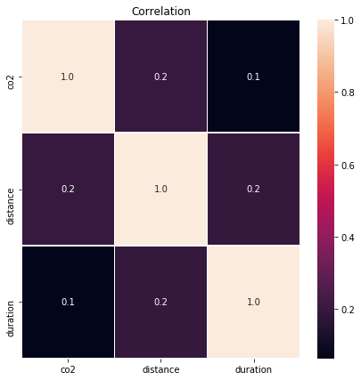

```python
# creating correlation map to investigate the relation between duration, distance, co2
import seaborn as sns

f,ax = plt.subplots(figsize=(7, 7))
sns.heatmap(main[['co2', 'distance', 'duration']].corr(), annot=True, linewidths=.5, fmt= '.1f')
plt.title('Correlation');
```

Now, it is clear that it is not the distance nor the duration imply the increased emissions of the co2 with a low correlation coofficient of 0.1 and 0.2

**However, to make further analysis to clarify the relationship between co2 emissions and time**

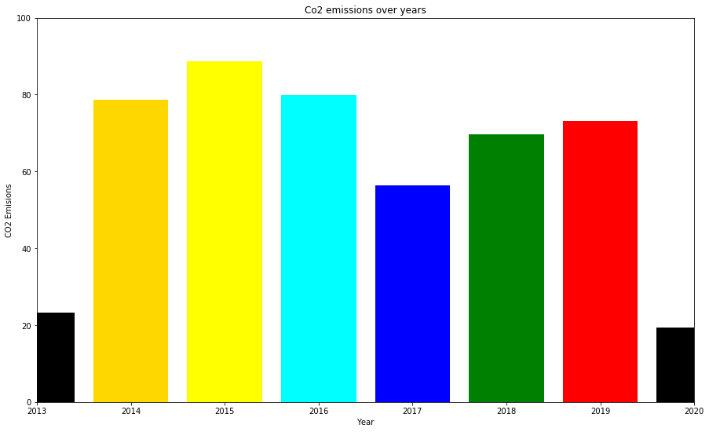

```python
# destribution of co2 emissions over time (line chart)
co2_year = main.groupby(["year"]).co2.sum().reset_index().sort_values(['year'], ascending=False)
plt.rcParams['figure.figsize']=(15,9)


submain7 = main.groupby(["year"]).co2.sum().reset_index().sort_values(['year'], ascending=False)

plt.bar(submain7.year, submain7.co2 , data = submain7, color=['black', 'red', 'green', 'blue', 'cyan','yellow','gold'])
plt.xlim((2013,2020))
plt.ylim((0,100))
plt.xlabel('Year')
plt.ylabel('CO2 Emisions')
plt.title('Co2 emissions over years');

plt.show()
```

```python
def filter_country(search_term):
    '''
    Filters the medals_df DataFrame to only contain rows whose Sport or Discipline
    columns contain the given search_term.
    '''
    return main[main["country"].str.contains(search_term, case=False) \
                     | main["region"].str.contains(search_term, case=False)\
                     | main["house"].str.contains(search_term, case=False)]
```

```python
def plot_countries(main):
    co2_year = main.groupby(["year"]).co2.sum().reset_index().sort_values(['year'], ascending=False)
    plt.rcParams['figure.figsize']=(15,4)

    co2_year.plot(kind = 'line', x = 'year', y = 'co2', alpha = 0.5, color = 'blue')
    plt.xlim((2013,2020))
    plt.ylim((0,100))
    plt.xlabel('Year')
    plt.ylabel('CO2 Emisions')
    plt.title('Co2 emissions over years');
```

```python
# import display to show DataFrame content
from IPython.display import display
# import the widgets interact function to automatically create interactive UI
from ipywidgets import interact

# decorate the search_and_plot_medals function using interact
# to create text field UI for search term
@interact(search='')
def search_and_plot_countries(search):
    '''
    Display medals by country when given a search term.
    '''
    filtered_country = filter_country(search)
    if len(filtered_country) == 0:
        print('No hits')
        return

    # show plot
    plot_countries(filtered_country)
```

```python
%matplotlib inline
from ipywidgets import interactive
import matplotlib.pyplot as plt
import numpy as np

def f(Year):

    submain1 = main[['continent','year','co2']]
    submain2 = submain1[submain1['year']==Year].groupby(["continent"]).co2.sum().reset_index()

    plt.bar(submain2.continent, submain2.co2 , data = submain2, color=['black', 'red', 'green', 'blue', 'cyan'])
    plt.xlabel("Continent")
    plt.ylabel("Co2 Emissions")
    plt.title("Breakdown of the co2 emissions for each contienant by year")
    plt.ylim(0, 90)
    plt.rcParams['figure.figsize']=(10,4)
    plt.show()

interactive_plot = interactive(f, Year=(2013,2020))
output = interactive_plot.children[-1]

interactive_plot
```

```python
%matplotlib inline
from ipywidgets import interactive
import matplotlib.pyplot as plt
import numpy as np

def f(Day):

    submain3 = main[['country','day','co2']]
    submain4 = submain3[submain3['day']==Day].groupby(["country"]).co2.sum().reset_index().sort_values(['co2'],
                                                                                                       ascending=False).head(5)



    fig, ax = plt.subplots(figsize=(15, 10), subplot_kw=dict(aspect="equal"))

    data = submain4.co2
    ingredients = submain4.country


    def func(pct, allvals):
        absolute = int(pct/100.*np.sum(allvals))
        return "{:.1f}%\n".format(pct, absolute)


    wedges, texts, autotexts = ax.pie(data, autopct=lambda pct: func(pct, data),
                                      textprops=dict(color="w"))

    ax.legend(wedges, ingredients,
              title="Countries",
              loc="center left",
              bbox_to_anchor=(1, 0, 0.5, 1))

    plt.setp(autotexts, size=12, weight="bold")

    ax.set_title("Co2 destribution over top 5 countries based on days")

    plt.show()




interactive_plot = interactive(f, Day=(1,31))
output = interactive_plot.children[-1]

interactive_plot
```

```python
%matplotlib inline
from ipywidgets import interactive
import matplotlib.pyplot as plt
import numpy as np

def f(Month):

    submain5 = main[['mode','month','co2']]
    submain5 = submain5.rename(columns={'mode' :'vehicle'})
    submain6 = submain5[submain5['month']==Month].groupby(["vehicle"]).co2.sum().reset_index()

    plt.bar(submain6.vehicle, submain6.co2 , data = submain6, color = "red")
    plt.xlabel("Vehicles")
    plt.ylabel("Co2 Emissions")
    plt.title("Vehicle co2 emissions based on Month")
    plt.ylim(0, 30)

    plt.show()

interactive_plot = interactive(f, Month=(1,12))
output = interactive_plot.children[-1]

interactive_plot
```

```python
%matplotlib inline
from ipywidgets import interactive
import matplotlib.pyplot as plt
import numpy as np

def f(Country):

    submain1 = main[['country','year','co2']]
    submain2 = submain1[submain1['country']==Country].groupby(["year"]).co2.sum().reset_index()

    plt.bar(submain2.year, submain2.co2 , data = submain2, color=['black', 'red', 'green', 'blue', 'cyan'])
    plt.xlabel("Year")
    plt.ylabel("Co2 Emissions")
    plt.title("Breakdown of the co2 emissions for each country over years")

    plt.rcParams['figure.figsize']=(10,4)
    plt.show()

interactive_plot = interactive(f, Country=main.country.drop_duplicates())
output = interactive_plot.children[-1]

interactive_plot
```

```python
%matplotlib inline
from ipywidgets import interactive
import matplotlib.pyplot as plt
import numpy as np

def f(Region):

    submain1 = main[['region','year','co2']]
    submain2 = submain1[submain1['region']==Region].groupby(["year"]).co2.sum().reset_index()

    plt.bar(submain2.year, submain2.co2 , data = submain2, color=['black', 'red', 'green', 'blue', 'cyan'])
    plt.xlabel("Year")
    plt.ylabel("Co2 Emissions")
    plt.title("Breakdown of the co2 emissions for each Region over years")

    plt.rcParams['figure.figsize']=(10,4)
    plt.show()

interactive_plot = interactive(f, Region=main.region.drop_duplicates())
output = interactive_plot.children[-1]

interactive_plot
```

```python
%matplotlib inline
from ipywidgets import interactive
import matplotlib.pyplot as plt
import numpy as np

def f(House):

    submain1 = main[['house','year','co2']]
    submain2 = submain1[submain1['house']==House].groupby(["year"]).co2.sum().reset_index()

    plt.bar(submain2.year, submain2.co2 , data = submain2, color=['black', 'red', 'green', 'blue', 'cyan'])
    plt.xlabel("Year")
    plt.ylabel("Co2 Emissions")
    plt.title("Breakdown of the co2 emissions for each House over years")

    plt.rcParams['figure.figsize']=(10,4)
    plt.show()

interactive_plot = interactive(f, House=main.house.drop_duplicates())
output = interactive_plot.children[-1]

interactive_plot
```

```python
from IPython.display import HTML

HTML('''<script>
code_show=true;
function code_toggle() {
 if (code_show){
 $('div.input').hide();
 } else {
 $('div.input').show();
 }
 code_show = !code_show
}
$( document ).ready(code_toggle);
</script>
<form action="javascript:code_toggle()"><input type="submit" value="Click here to toggle on/off the raw code."></form>''')
```